# lecture9 slides

- Linear classification models / linear classifiers (recall)
- Perceptron
  - Demo
- Logistic regression solution
  - Solve logistic regression problem, fit on data.

# Linear classifiers

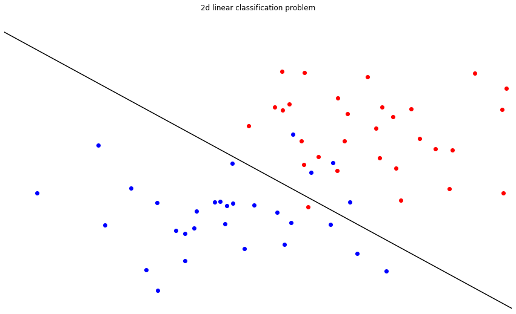

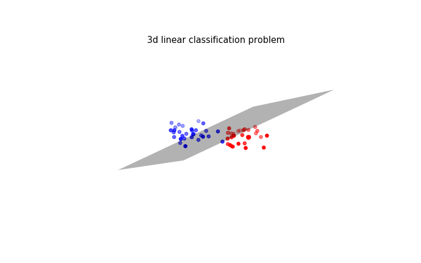

Classify using $w^T\phi$.

Q: What does $w$ mean here?

A: $w$ is the normal vector of decision boundary.

$w^T\phi$ is basically projection of $\phi$ on $w$.

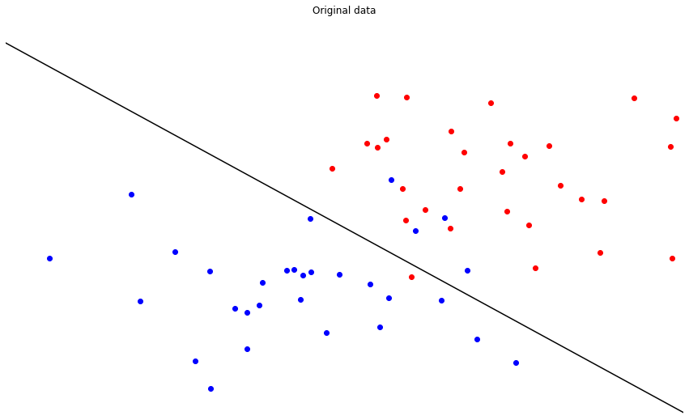

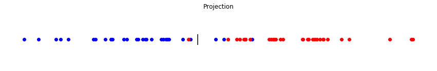

Perceptron divides data using $w^T\phi$, But logistic regression uses $\sigma(w^T\phi)$.

Consider perceptron and logistic regression models that fit on a data and give the same $w$ vectors.

Q: What would be the difference while predicting.

A: Actually nothing's different when predicting. $P(C_1|\phi) = \sigma(w^T\phi) > 0.5 \Leftrightarrow w^T\phi > 0$

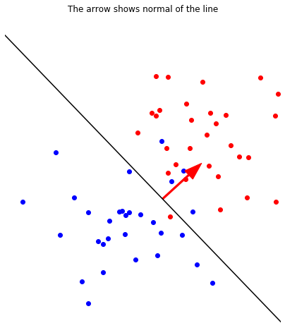

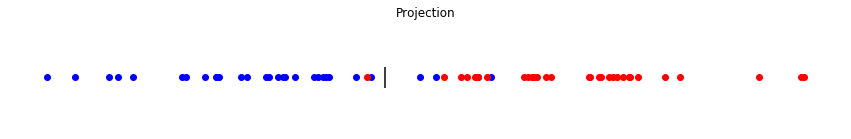

## Fisher's criterion

Maximise between class covariance, minimize in-class covariance.

Criterion is:

$$J(w) = \frac{S_{between\_class}}{S_1 + S_2}$$

Where $S_1$ and $S_2$ are variances of classes after projection, and $S_{between\_class}$ is covariance between classes after projection.

This is the criterion how to project. It doesn't choose decision boundary.

# Perceptron

We penalize wrong classified datapoints.

$$Loss = \sum_{\phi \in misclassified} distance(line, \phi) = |w^T\phi|$$

$$Loss = -\sum_{\phi \in misclassified} label\cdot w^T\phi $$

Perceptron algorithm:

- initalize weights
- iterate over data several times
- calculate loss on each single datapoint
- if missclassified, add $label\cdot \phi$ to $w$
  - it's obvious, that loss will decrease on that single datapoint.

## Theorem: Perceptron converges on linearly seperable data in finite steps.

Perceptron problem: It's hard to identify, is it a slow convergence or data is not linearly separable.

### Mark1 perceptron model

[figure not shown]

### Rosenblatt with

[figure not shown]

## Logistic Regression

Categorical cross entropy

$$Loss(w) = -\sum_{n=1}^N t_n \ln(y_n) + (1 - t_n) \ln(1-y_n)$$

$$Loss(w)= -\sum \ln(y_n)\ if\ t_n\ is\ 1\ and\ \ln(1-y_n)\ otherwise$$

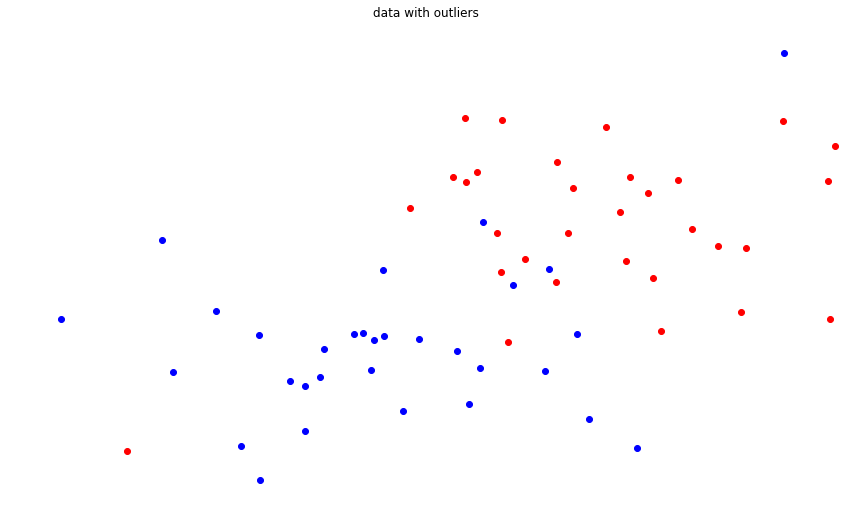

We can assume out initial labels have some chance to be wrong with probability $\epsilon$

$$Loss(w) = -\sum_{n=1}^N t_n ((1-\epsilon)\ln(y_n)+\epsilon\ln(1-y_n)) + (1 - t_n) ((1-\epsilon)\ln(1-y_n)+\epsilon\ln(y_n))$$

Q: So how to minimize Loss function.

# Gradient descent

[figure not shown]

Gradient descent algorithm:

- Start with some point
- calculate gradient
- move in opposite direction
- repeat from step 2
- stop when gradient is 0 (or almost equal to 0)

3 basic types of gradient descent algorithms are:

- batch gradient descent:

  Calculates gradient on the loss function
- stochastic gradient descent:

  Calculates gradient on a single point
- minibatch gradient descent:

  Divides data into random minibatches of fixed size, and calculates gradient on them

## Step size

[figure not shown]

$$Loss_{perceptron}(w) = -\sum_{\phi \in missclassified} label\cdot w^T\phi$$

$$\nabla_w Loss_{perceptron}(w) = -\sum_{\phi \in missclassified} label\cdot \phi$$

Basically perceptron's solution is stochastic gradient descent algorithm.

Q: Why haven't we choosed step size in perceptron

A: multipling gradient with $\alpha$ is equivalent to dividing $w$ with $\alpha$. So, instead of using step size we can initialize differently.

Other types of gradient descents:

- momentum
  - Use velocity instead of gradient
  - Update velocity on each step with some coefficient, e.g. $vel^{(new)} = 0.9\cdot vel^{old} - 0.1\nabla loss$
- Newton-Raphson
  - calculate hessian matrix and gradient
  - $w^{(new)} = w^{old} - H^{-1}\nabla Loss(w)$

Newton-Raphson method solves linear regression problem in one step.

Problems:

It's not easy to choose learning rate. Some algorithms update it over time.

## Let's fit logistic regression

$$\nabla Loss(w) = \sum_{n=1}^N (y_n-t_n)\phi_n = \Phi^T(y-t)$$

$$\nabla H(w) = \sum_{n=1}^N y_n(1-y_n)\phi_n\phi_n^T = \Phi^TR\Phi$$

Where $R$ is diagonal matrix of $y_n(1-y_n)$-s.